# Learning activation functions in DNNs

## Introduction

Activation(=transfer) functions are the non linear operations in neural networks. We are looking at frameworks for learning these transfer functions:

- Optimal transport transfer function
- Iterative Distribution Transfer (IDT)
- Nadaraya-Watson transfer function
- L2 transfer function
- Deep Spline Neural Networks

## Optimal Transport (1D)

Consider two PDFs \(f\) and \(g\) and their CDFs noted \(F\) (with \(dF(x)=f(x)\ dx\)) and \(G\) (with \(dG(x)=g(x)\ dx\)) respectively, for random variables \(x\) and \(y\).

**Problem:** How to find a (bijective and differentiable) transformation \(\phi\) such that \(y=\phi(x)\) for two random variables \(x\sim f(x)\) and \(y \sim g(y)\)?

\[ \begin{array}{lc} &\\ \text{Solution (1D):} & \phi(x)=G^{-1}\circ F(x)\\ &\\ \end{array} \]

This solution has also been shown to minimize the transport cost (Quadratic Wasserstein) :

\[ \mathcal{W} = \mathbb{E}_{(x,y)\sim\pi} \left[ |x-y|^2 \right\rbrack \quad \text{s.t.}\quad f=\int \pi\ dy \quad \text{and}\quad g=\int \pi\ dx \]

[Introduction to Optimal Transport](https://www.math.cmu.edu/~mthorpe/OTNotes) M. Thorpe 2018

## Applications (1D)

**Example Equalization: \(y=\phi(x)=Id\circ F(x)\)** using \(g\equiv \mathcal{U}\) (uniform) \(G=Id=G^{-1}\) (identity function)

**Example Bridge/synthesis: \(y=\phi(x)=G^{-1}\circ Id(x)\)** synthesis samples \(y\sim g\) from samples \(x\) easily generated \(x\sim \mathcal{U}\)

## Iterative Distribution Transfer

The solution \(\phi(x)=G^{-1}\circ F(x)\) works for r.v. \(x,y\in \mathbb{R}\) but what about if \(\mathbf{x},\mathbf{y}\in\mathbb{R}^d\) ?

- Iterative Distribution Transfer (IDT) algorithm proposed by Pitie et al uses the 1D solution iteratively by projecting multidimensional data for \(x\) and \(y\) onto 1D spaces.
- The directions for projection are chosen orthogonal spanning \(\mathbb{R}^d\), potentially with redundancy. To vary these directions from one iteration to the next, a random rotation is used.
- IDT has been applied to colour pixels (\(d=3\)).

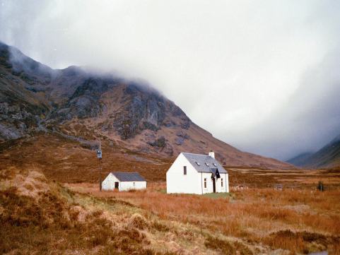

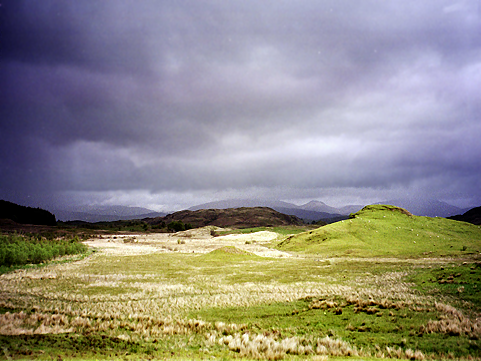

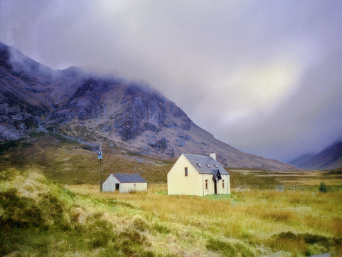

\(x\in\mathbb{R}^3\)

\(y\in\mathbb{R}^3\)

\(\phi_{IDT}(x)\in\mathbb{R}^3\)

[Automated colour grading using colour distribution transfer](https://github.com/frcs/colour-transfer) Pitie, Kokaram & Dahyot [[DOI:10.1016/j.cviu.2006.11.011](http://doi.org/10.1016/j.cviu.2006.11.011)]

## Iterative Distribution Transfer

|  | IDT has a similar structured to a DNN: a linear projection followed by a non linear mapping, this is repeated iteratively. |
| --- | --- |

[Automated colour grading using colour distribution transfer](https://github.com/frcs/colour-transfer) Pitie, Kokaram & Dahyot [[DOI:10.1016/j.cviu.2006.11.011](http://doi.org/10.1016/j.cviu.2006.11.011)]

## Iterative Distribution Transfer

Using Zhang et al (2021) taxonomy, :

```bash
Optimal Transport Methods
│
├───Regularization based
│   └─── ...
│
├───Projection based
   ├───Random Projection
   │    └───Iterative Distribution Transfer (IDT)
   │
   ├───Projection Pursuit
```

A Review on Modern Computational Optimal Transport Methods with Applications in Biomedical Research, J. Zhang et al 2021 [[arXiv:2008.02995.pdf](https://arxiv.org/pdf/2008.02995.pdf)]

## Transfer function \(\phi_{OT}\)

Solution \(\phi_{OT}(x)=G^{-1}\circ F(x)\) may not be capturing well the actual process (i.e. joint distribution \(\pi(x,y)\)) that generated the data \(\lbrace (x^{(i)},y^{(i)})\rbrace_{i=1,\cdots,n}\).

[output not shown]

Patch-Based Colour Transfer with Optimal Transport. Alghamdi, Grogan & Dahyot [[DOI:10.23919/EUSIPCO.2019.8902611](http://doi.org/10.23919/EUSIPCO.2019.8902611)]

## Transfer function \(\phi_{NW}\)

\[ \hat{y}=\phi_{NW}(x)=\mathbb{E}[y|x] =\int y \ p_{y|x}(y|x) dy \simeq \frac{\sum_{i=1}^n y^{(i)} \ k_h(x-x^{(i)})}{\sum_{i=1}^n k_h(x-x^{(i)})} \]

[output not shown]

[Iterative Nadaraya-Watson Distribution Transfer for Colour Grading](https://arxiv.org/pdf/2006.09208.pdf). Alghamdi & Dahyot [[DOI:10.1109/MMSP48831.2020.9287097](https://doi.org/10.1109/MMSP48831.2020.9287097)]

## Transfer function \(\phi_{L2}\)

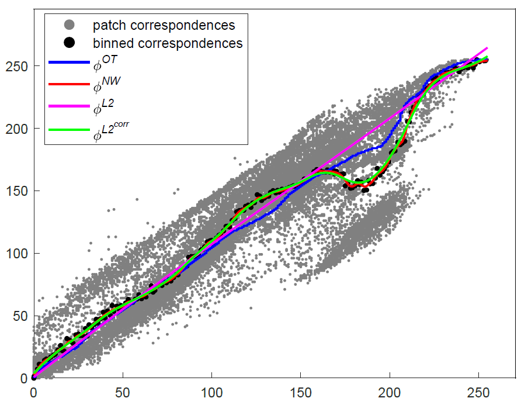

We have recently proposed to fit a spline function with correspondences \(\phi_{L2}^{Corr}\) and without \(\phi_{L2}\) that minimizes the robust \(L2\) distance between GMMs \(f\) and \(g\).

[Sliced L2 Distance for Colour Grading](https://arxiv.org/pdf/2102.09297.pdf) Alghamdi & Dahyot [[arXiv:2102.09297](https://arxiv.org/pdf/2102.09297.pdf), EUSIPCO 2021 to appear]

## Deep Neural Networks

In DNNs, the machine model corresponds to a function \(\mathcal{M}_{\theta}\) designed by compositions of a linear and non linear functions:

\[ \mathcal{M}_{\theta}(x)= \mathrm{W}_L \circ \cdots \underbrace{\phi_l \circ \mathrm{W}_l}_{\text{Layer } l} \circ \cdots \circ \phi_1 \circ \mathrm{W}_1 (x) \] Layer \(l\) : linear transformation followed by a point wise non linear activation: \[ \phi_l(x)=\left(\phi_{l,1}(x_1),\cdots,\phi_{l,N_l}(x_{N_l}) \right) \] where the scalar map \(\phi_{l,n}:\mathbb{R} \rightarrow \mathbb{R}\) is the activation or transfer function of the neuron indexed by \((l, n)\).

## Transfer (Activation) Functions

[output not shown]

## Learnt activation functions

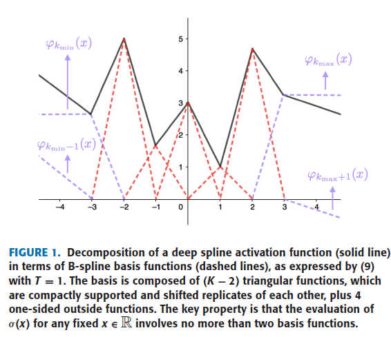

Bohra et al (2020) proposed to DNNs with spline based transfer-activation functions. The DNN is optimized end-to-end.

[Learning Activation Functions in Deep (Spline) Neural Networks](https://doi.org/10.1109/OJSP.2020.3039379) Bohra et al [[DOI:10.1109/OJSP.2020.3039379](https://doi.org/10.1109/OJSP.2020.3039379)]

## Future works

- Is learning direction of projections needed? (cf. random projections in IDT, and wavelets chosen in scattering networks)
- Is end to end optimization needed for learning activation functions?
- Can (cost effective and accurate) DNNs be designed using pre-set projections + learnt activation functions?
- …